# Country Report

Nick Parker

3/13/2022

# Report on - AL

## Project Description

This project explores how sex, religious affiliation, and income influence the degree to which respondents agree with the following statements:

- When a mother works for pay, the children suffer
- When jobs are scarce, employers should give priority to [NATIONALITY] people over immigrants

The data used in this analysis was generated as part of the 2017 European Value Study (EVS). The EVS is described as “a large-scale, cross-national and longitudinal survey research program on how Europeans think about family, work, religion, politics, and society. Repeated every nine years in an increasing number of countries, the survey provides insights into the ideas, beliefs, preferences, attitudes, values, and opinions of citizens all over Europe.”

## Descriptive Statistics

```r
library(tidyverse)
library(haven)
library(psych)
library(texreg)

data<- read.csv("/Users/nicholasparker/Dropbox/JPSM/MWDS/EVS/data/clean/data_clean.csv")

data_clean<- data %>%
  select(-X) %>%
  filter(country==params$nms)
```

```r
data_clean$religion[data_clean$religion==1]<- "Roman Catholic"
data_clean$religion[data_clean$religion==2]<- "Protestant"
data_clean$religion[data_clean$religion==3]<- "Free Church"
data_clean$religion[data_clean$religion==4]<- "Jew"
data_clean$religion[data_clean$religion==5]<- "Muslim"
data_clean$religion[data_clean$religion==6]<- "Hindu"
data_clean$religion[data_clean$religion==7]<- "Buddhist"
data_clean$religion[data_clean$religion==8]<- "Orthodox"
data_clean$religion[data_clean$religion==9]<- "Other"

data_continuous <- data_clean %>%
  select(income, age)

data_categorical <- data_clean %>%
  select(-income, -age)

table_continuous <- describe(data_continuous)

table_categorical <- summary(data_categorical)

library(knitr)

table_categorical <- summary(data_categorical)

knitr::kable(table_continuous)
```

|  | vars | n | mean | sd | median | trimmed | mad | min | max | range | skew | kurtosis | se |
| --- | --- | --- | --- | --- | --- | --- | --- | --- | --- | --- | --- | --- | --- |
| income | 1 | 1435 | 3.798606 | 2.548935 | 4 | 3.805048 | 2.9652 | -2 | 10 | 12 | -0.0348522 | -0.1677969 | 0.0672873 |
| age | 2 | 1435 | 45.418118 | 16.554823 | 46 | 45.292428 | 19.2738 | -2 | 82 | 84 | 0.0015558 | -0.9065573 | 0.4370173 |

```r
knitr::kable(table_categorical)
```

|  | suffering_mother | jobs_scarce | religion | education | country | sex |
| --- | --- | --- | --- | --- | --- | --- |
|  | Min. :-2.000 | Min. :-1.000 | Length:1435 | Min. :1.000 | AL :1435 | Min. :1.000 |
|  | 1st Qu.: 2.000 | 1st Qu.: 1.000 | Class :character | 1st Qu.:1.000 | AM : 0 | 1st Qu.:1.000 |
|  | Median : 2.000 | Median : 2.000 | Mode :character | Median :2.000 | AT : 0 | Median :2.000 |
|  | Mean : 2.254 | Mean : 2.008 | NA | Mean :1.698 | AZ : 0 | Mean :1.631 |
|  | 3rd Qu.: 3.000 | 3rd Qu.: 2.000 | NA | 3rd Qu.:2.000 | BA : 0 | 3rd Qu.:2.000 |
|  | Max. : 4.000 | Max. : 5.000 | NA | Max. :3.000 | BG : 0 | Max. :2.000 |
|  | NA | NA | NA | NA | (Other): 0 | NA |

```r
## Create age deciles

data_clean_age<- data_clean %>%
  select(age,suffering_mother,jobs_scarce)

data_clean_age_suffering<- data_clean_age %>%
  group_by(age) %>%
  summarise(mean_age_suffering = mean(suffering_mother)) %>%
  filter(age>0)

data_clean_religion_suffering<- data_clean %>%
  group_by(religion) %>%
  summarise(mean_religion_suffering = mean(suffering_mother)) %>%
  filter(religion>0)

data_clean_age_jobs<- data_clean_age %>%
  group_by(age) %>%
  summarise(mean_age_jobs= mean(jobs_scarce)) %>%
  filter(age>0)

data_clean_religion_jobs<- data_clean %>%
  group_by(religion) %>%
  summarise(mean_religion_jobs = mean(jobs_scarce)) %>%
  filter(religion>0)

data_merge_age <- left_join(data_clean_age_suffering, data_clean_age_jobs, by="age")

data_long_age<- data_merge_age %>%
  pivot_longer(
    cols = "mean_age_suffering":"mean_age_jobs",
    names_to = "new",
    values_to = "values"
  )

data_merge_religion <- left_join(data_clean_religion_suffering, data_clean_religion_jobs, by="religion")

data_long_religion<- data_merge_religion %>%
  pivot_longer(
    cols = "mean_religion_suffering":"mean_religion_jobs",
    names_to = "new",
    values_to = "values"
  )
```

## Figures

Figure 1 illustrates that, as the age of a respondent increases, they are more likely to agree with the idea that mothers choosing to work for pay will harm their children. This relationship also appears to hold true for the statement that when jobs are scarce, they should be given to citizens before imigrants.

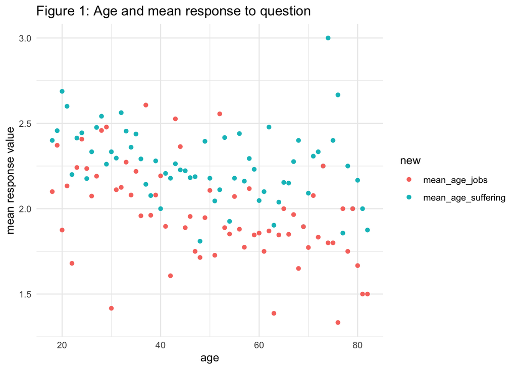

```r
ggplot(data = data_long_age, aes(age,values, color=new))+
  theme_minimal()+
  geom_point() +
  xlab("age") +
  ylab("mean response value")+
  ggtitle("Figure 1: Age and mean response to question")
```

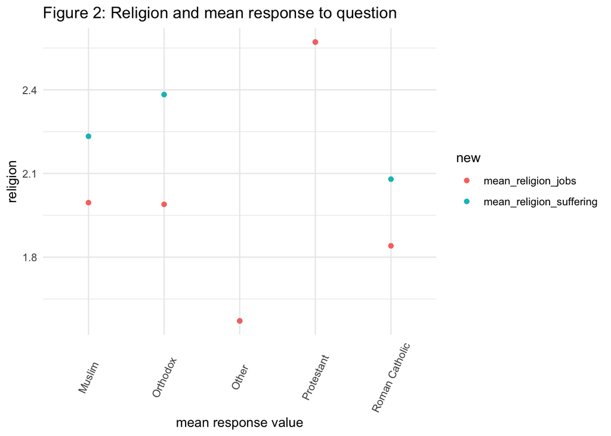

```r
ggplot(data = data_long_religion, aes(religion, values, color=new))+
  theme_minimal()+
  geom_point() +
  xlab("mean response value") +
  ylab("religion")+
  theme(axis.text.x = element_text(angle=65,vjust=0.5))+
  ggtitle("Figure 2: Religion and mean response to question")
```

## Statistical Tests

```r
suffering.mother.lm<-lm(suffering_mother ~ education + age + age^2 + sex, data = data_clean)

jobs.scarce.lm<-lm(jobs_scarce ~ education + age + age^2 + sex, data = data_clean)

reg_table <- htmlreg(list(suffering.mother.lm, jobs.scarce.lm),
    dcolumn = TRUE,
    booktabs = TRUE,
    use.packages = TRUE,
    label = "tab:1",
    caption = "Regression Estimation Results", float.pos = "hb",
    custom.model.names = c("Working Mother", "Job Scarcity"))

reg_table
```

Regression Estimation Results

|  | Working Mother | Job Scarcity |
| --- | --- | --- |
| (Intercept) | 2.23*** | 1.96*** |
|  | (0.13) | (0.17) |
| education | 0.14*** | 0.16*** |
|  | (0.03) | (0.04) |
| age | -0.00** | -0.01*** |
|  | (0.00) | (0.00) |
| sex | -0.01 | 0.06 |
|  | (0.05) | (0.06) |
| R<sup>2</sup> | 0.02 | 0.03 |
| Adj. R<sup>2</sup> | 0.02 | 0.03 |
| Num. obs. | 1435 | 1435 |

***p < 0.001; **p < 0.01; *p < 0.05